# EP09

Equipo 2

2024-12-02

#### Contexto:

#### Un estudio recolectó medidas anatómicas de 247 hombres y 260 mujeres (Heinz et al., 2003). El estudio incluyó nueve mediciones del esqueleto (ocho diámetros y una profundidad de hueso a hueso) y doce mediciones de grosor (circunferencias) que incluyen el tejido.

#### Se nos pide completar las siguientes tareas:

#### 1. Definir la semilla a utilizar, que corresponde a los últimos cuatro dígitos del RUN (sin considerar el dígito verificador) del integrante de menor edad del equipo.

#### 2. Seleccionar una muestra aleatoria de 100 mujeres (si la semilla es un número par) o 100 hombres (si la semilla es impar), y separar 70 casos para trabajar en la construcción de modelos y 30 para su evaluación en datos no vistos.

#### 3. Seleccionar de forma aleatoria ocho posibles variables predictoras.

#### 4. Seleccionar, de las otras variables, una que el equipo considere que podría ser útil para predecir la variable Peso (sin considerar la estatura), justificando bien esta selección.

#### 5. Usando el entorno R y paquetes estándares, construir un modelo de regresión lineal simple con el predictor seleccionado en el paso anterior.

#### 6. Usando herramientas estándares para la exploración de modelos del entorno R, buscar entre dos y cinco predictores de entre las variables seleccionadas al azar en el punto 3, para agregar al modelo de regresión lineal simple obtenido en el paso 5.

#### 7. Evaluar la bondad de ajuste (incluyendo el análisis de casos atípicos y casos influyentes) y la generalidad (condiciones para RLM) de los modelos y “arreglarlos” en caso de que presenten algún problema.

#### 8. Evaluar el poder predictivo del modelo con los datos no utilizados para construirlo.

### Obtención de datos:

Primero leemos los datos.

```r
datosGenerales <- read.csv2("EP09 Datos.csv")
head(datosGenerales)
```

```
##   Biacromial.diameter Biiliac.diameter Bitrochanteric.diameter Chest.depth
## 1                42.9             26.0                    31.5        17.7
## 2                43.7             28.5                    33.5        16.9
## 3                40.1             28.2                    33.3        20.9
## 4                44.3             29.9                    34.0        18.4
## 5                42.5             29.9                    34.0        21.5
## 6                43.3             27.0                    31.5        19.6
##   Chest.diameter Elbows.diameter Wrists.diameter Knees.diameter Ankles.diameter
## 1           28.0            13.1            10.4           18.8            14.1
## 2           30.8            14.0            11.8           20.6            15.1
## 3           31.7            13.9            10.9           19.7            14.1
## 4           28.2            13.9            11.2           20.9            15.0
## 5           29.4            15.2            11.6           20.7            14.9
## 6           31.3            14.0            11.5           18.8            13.9
##   Shoulder.Girth Chest.Girth Waist.Girth Navel.Girth Hip.Girth Thigh.Girth
```

[output cut: 20 more lines]

Luego fijamos una semilla y, como la semilla es impar, obtenemos una muestra aleatoria de 100 hombres, donde usamos 70 muestras para generar el modelo de regresión simple y múltiple. Además, obtenemos ocho variables aleatoriamente como posibles predictoras.

```r
set.seed(7525)

datos = datosGenerales %>% filter(Gender == 1) %>% sample_n(100)

i_datos = sample.int(n = 100, size = 70, replace = FALSE)

datosModelos = datos[i_datos,]
datosPruebas = datos[-i_datos,]

predictores = sample(colnames(datos), 8)

print(predictores)
```

```
## [1] "Knee.Girth"          "Weight"              "Chest.diameter"
## [4] "Wrist.Minimum.Girth" "Thigh.Girth"         "Height"
## [7] "Calf.Maximum.Girth"  "Gender"
```

### Modelo de regresión lineal simple:

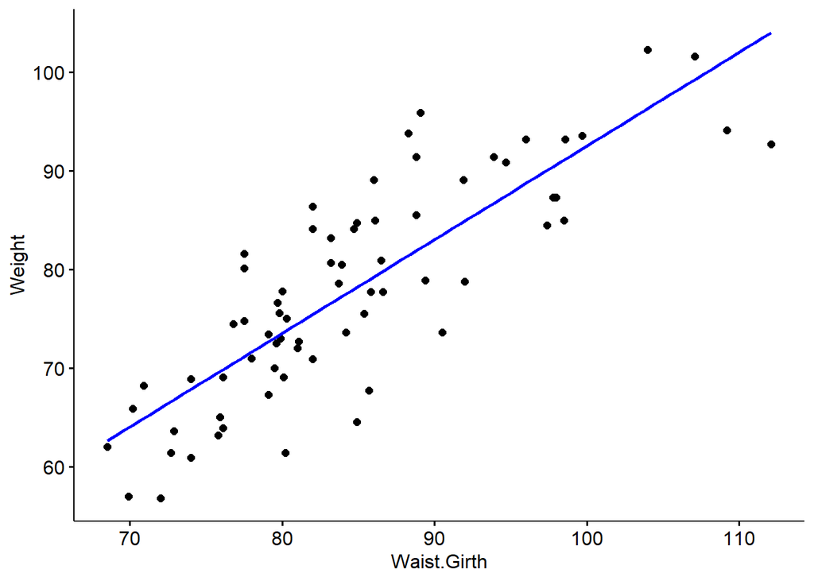

```r
p1 <- ggscatter(datosModelos, x = "Waist.Girth", y = "Weight",
                add = "reg.line", add.params = list(color = "blue"))
print(p1)
```

```r
modeloSimple = lm(Weight ~ Waist.Girth, data = datosModelos)
print(summary(modeloSimple))
```

```
##
## Call:
## lm(formula = Weight ~ Waist.Girth, data = datosModelos)
##
## Residuals:
##     Min      1Q  Median      3Q     Max
## -13.685  -4.529   0.144   4.099  13.726
##
## Coefficients:
##             Estimate Std. Error t value Pr(>|t|)
## (Intercept) -2.45654    6.65056  -0.369    0.713
## Waist.Girth  0.94984    0.07811  12.160   <2e-16 ***
## ---
## Signif. codes:  0 '***' 0.001 '**' 0.01 '*' 0.05 '.' 0.1 ' ' 1
##
## Residual standard error: 6.222 on 68 degrees of freedom
## Multiple R-squared:  0.685,  Adjusted R-squared:  0.6803
## F-statistic: 147.9 on 1 and 68 DF,  p-value: < 2.2e-16
```

### Selección de variables aleatorias para agregar al modelo:

Empezamos a crear un modelo múltiple con base en el modelo simple aplicando la estrategia de eliminación hacia atrás, para esto creamos un dataframe solo con las variables obtenidas aleatoriamente y generamos un modelo considerando todas las variables obtenidas como predictoras, para la eliminación de predictores, eliminaremos el predictor que presente un menor valor del estadístico F.

```r
datosModelos = datosModelos %>%
  select(Weight, Waist.Girth, Knee.Girth, Chest.diameter, Wrist.Minimum.Girth, Thigh.Girth, Height, Calf.Maximum.Girth) # Gender no aplica

modeloCompleto = lm(Weight ~ ., data = datosModelos)
print(summary(modeloCompleto))
```

```
##
## Call:
## lm(formula = Weight ~ ., data = datosModelos)
##
## Residuals:
##     Min      1Q  Median      3Q     Max
## -6.1892 -1.4165 -0.1315  1.4549  4.1647
##
## Coefficients:
##                       Estimate Std. Error t value Pr(>|t|)
## (Intercept)         -120.65815    7.10876 -16.973  < 2e-16 ***
## Waist.Girth            0.49512    0.04073  12.157  < 2e-16 ***
## Knee.Girth             0.21484    0.19154   1.122  0.26634
## Chest.diameter         0.23899    0.18454   1.295  0.20009
## Wrist.Minimum.Girth    1.30415    0.34218   3.811  0.00032 ***
## Thigh.Girth            0.84248    0.09320   9.040 6.35e-13 ***
## Height                 0.30343    0.04627   6.557 1.25e-08 ***
## Calf.Maximum.Girth     0.46901    0.17430   2.691  0.00915 **
## ---
## Signif. codes:  0 '***' 0.001 '**' 0.01 '*' 0.05 '.' 0.1 ' ' 1
##
## Residual standard error: 2.249 on 62 degrees of freedom
## Multiple R-squared:  0.9625, Adjusted R-squared:  0.9582
## F-statistic: 227.1 on 7 and 62 DF,  p-value: < 2.2e-16
```

Ahora comenzamos con la regresión paso a paso, donde primero generamos los resultados de los modelos al eliminar un predictor.

```r
paso = drop1(modeloCompleto, test = "F")
print(paso, digits = 3, signif.legend = TRUE)
```

```
## Single term deletions
##
## Model:
## Weight ~ Waist.Girth + Knee.Girth + Chest.diameter + Wrist.Minimum.Girth +
##     Thigh.Girth + Height + Calf.Maximum.Girth
##                     Df Sum of Sq  RSS AIC F value  Pr(>F)
## <none>                            314 121
## Waist.Girth          1       748 1061 204  147.80 < 2e-16 ***
## Knee.Girth           1         6  320 120    1.26 0.26634
## Chest.diameter       1         8  322 121    1.68 0.20009
## Wrist.Minimum.Girth  1        73  387 134   14.53 0.00032 ***
## Thigh.Girth          1       413  727 178   81.72 6.4e-13 ***
## Height               1       218  531 156   43.00 1.2e-08 ***
## Calf.Maximum.Girth   1        37  350 127    7.24 0.00915 **
## ---
## Signif. codes:  0 '***' 0.001 '**' 0.01 '*' 0.05 '.' 0.1 ' ' 1
```

Observamos que el predictor Knee.Girth tiene un menor valor del estadístico F por lo que lo eliminamos del modelo y hacemos otro paso más de la regresión paso a paso

```r
modeloMultiple1 = update(modeloCompleto, . ~ . - Knee.Girth)

paso = drop1(modeloMultiple1, test = "F")
print(paso, digits = 3, signif.legend = TRUE)
```

```
## Single term deletions
##
## Model:
## Weight ~ Waist.Girth + Chest.diameter + Wrist.Minimum.Girth +
##     Thigh.Girth + Height + Calf.Maximum.Girth
##                     Df Sum of Sq  RSS AIC F value  Pr(>F)
## <none>                            320 120
## Waist.Girth          1       820 1140 207  161.43 < 2e-16 ***
## Chest.diameter       1         9  329 120    1.83 0.18117
## Wrist.Minimum.Girth  1        76  396 133   14.96 0.00026 ***
## Thigh.Girth          1       467  787 181   91.85 6.4e-14 ***
## Height               1       248  568 158   48.80 2.1e-09 ***
## Calf.Maximum.Girth   1        55  375 130   10.82 0.00164 **
## ---
## Signif. codes:  0 '***' 0.001 '**' 0.01 '*' 0.05 '.' 0.1 ' ' 1
```

Observamos que el predictor Chest.diameter tiene un menor valor del estadístico F por lo que lo eliminamos del modelo y hacemos otro paso más de la regresión paso a paso

```r
modeloMultiple2 = update(modeloMultiple1, . ~ . - Chest.diameter)

paso = drop1(modeloMultiple2, test = "F")
print(paso, digits = 3, signif.legend = TRUE)
```

```
## Single term deletions
##
## Model:
## Weight ~ Waist.Girth + Wrist.Minimum.Girth + Thigh.Girth + Height +
##     Calf.Maximum.Girth
##                     Df Sum of Sq  RSS AIC F value  Pr(>F)
## <none>                            329 120
## Waist.Girth          1      1170 1499 224   227.3 < 2e-16 ***
## Wrist.Minimum.Girth  1       103  432 137    19.9 3.3e-05 ***
## Thigh.Girth          1       473  802 181    92.0 5.4e-14 ***
## Height               1       277  607 161    53.9 4.7e-10 ***
## Calf.Maximum.Girth   1        56  385 129    10.9  0.0016 **
## ---
## Signif. codes:  0 '***' 0.001 '**' 0.01 '*' 0.05 '.' 0.1 ' ' 1
```

Observamos que el predictor Calf.Maximum.Girth. Tiene un menor valor del estadístico F por lo que lo eliminamos del modelo y hacemos otro paso más de la regresión paso a paso. Cabe resaltar que, si bien tiene un menor valor del estadístico F, también posee un valor p muy pequeño, por lo cual comparamos el modelo con y sin este predictor.

```r
modeloMultiple3 = update(modeloMultiple2, . ~ . - Calf.Maximum.Girth)
print(summary(modeloMultiple2))
```

```
##
## Call:
## lm(formula = Weight ~ Waist.Girth + Wrist.Minimum.Girth + Thigh.Girth +
##     Height + Calf.Maximum.Girth, data = datosModelos)
##
## Residuals:
##    Min     1Q Median     3Q    Max
## -7.009 -1.179  0.011  1.552  4.765
##
## Coefficients:
##                       Estimate Std. Error t value Pr(>|t|)
## (Intercept)         -120.10528    7.16104 -16.772  < 2e-16 ***
## Waist.Girth            0.53093    0.03521  15.078  < 2e-16 ***
## Wrist.Minimum.Girth    1.46536    0.32820   4.465 3.33e-05 ***
## Thigh.Girth            0.87323    0.09107   9.589 5.37e-14 ***
## Height                 0.32714    0.04457   7.340 4.69e-10 ***
## Calf.Maximum.Girth     0.54343    0.16448   3.304  0.00156 **
## ---
## Signif. codes:  0 '***' 0.001 '**' 0.01 '*' 0.05 '.' 0.1 ' ' 1
##
## Residual standard error: 2.268 on 64 degrees of freedom
## Multiple R-squared:  0.9606, Adjusted R-squared:  0.9575
## F-statistic:   312 on 5 and 64 DF,  p-value: < 2.2e-16
```

```r
print(summary(modeloMultiple3))
```

```
##
## Call:
## lm(formula = Weight ~ Waist.Girth + Wrist.Minimum.Girth + Thigh.Girth +
##     Height, data = datosModelos)
##
## Residuals:
##     Min      1Q  Median      3Q     Max
## -5.3301 -1.7007 -0.1013  1.7207  5.0898
##
## Coefficients:
##                       Estimate Std. Error t value Pr(>|t|)
## (Intercept)         -116.61902    7.60392 -15.337  < 2e-16 ***
## Waist.Girth            0.53610    0.03777  14.195  < 2e-16 ***
## Wrist.Minimum.Girth    1.76646    0.33849   5.219 2.02e-06 ***
## Thigh.Girth            1.02141    0.08509  12.004  < 2e-16 ***
## Height                 0.34287    0.04757   7.207 7.45e-10 ***
## ---
## Signif. codes:  0 '***' 0.001 '**' 0.01 '*' 0.05 '.' 0.1 ' ' 1
##
## Residual standard error: 2.435 on 65 degrees of freedom
## Multiple R-squared:  0.9539, Adjusted R-squared:  0.951
## F-statistic:   336 on 4 and 65 DF,  p-value: < 2.2e-16
```

```r
modeloMultiple = modeloMultiple2
```

Observamos que el modelo con el predictor Calf.Maximum.Girth posee un mayor valor R cuadrado que el modelo sin este predictor, por lo cual dejamos el modelo que contiene este predictor.

Se agregaron 4 nuevos predictores al modelo: Wrist.Minimum.Girth, Thigh.Girth, Height y Calf.Maximum.Girth

### Bondad de ajuste de los modelos

Considerando un nivel de significancia estándar de 0.05, podemos afirmar que:

Con respecto al modelo simple, podemos observar que se obtiene un r cuadrado de 0,685 por lo cual podemos afirmar que el modelo basado en el grosor de la cintura reduce en un 68,5% la varianza aleatoria respecto al modelo nulo, además de que esta reducción es significativa, puesto que el valor p obtenido del modelo es mucho menor al nivel de significancia establecido.

Y con respecto al modelo múltiple que considera como predictores las variables que representan, el grosor de la cintura, el grosor promedio de la parte más delgada de ambas muñecas, el grosor promedio de ambos muslos bajo el pliegue del glúteo, la altura y el grosor promedio de la parte más ancha de ambas pantorrillas, este obtiene un r d}cuadrado de 0,9606 por lo cual podemos afirmar que el modelo múltiple reduce en un 96,05% la varianza aleatoria respecto al modelo nulo, además de que esta reducción es significativa, puesto que el valor p obtenido del modelo es mucho menor al nivel de significancia establecido.

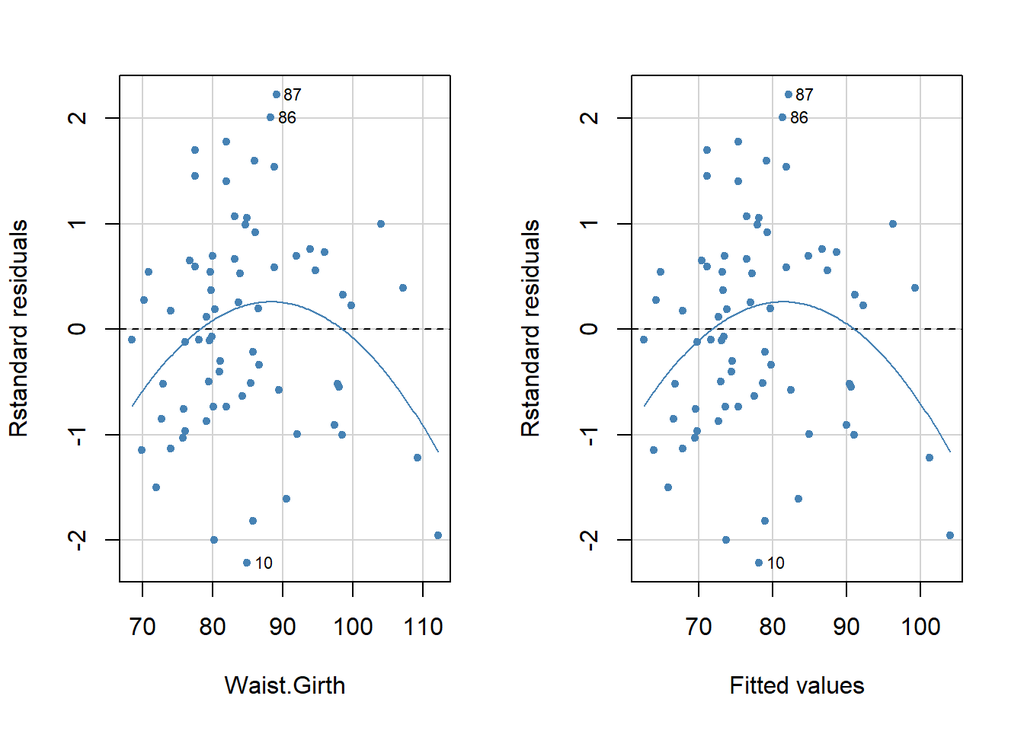

```
##             Test stat Pr(>|Test stat|)
## Waist.Girth    -2.478          0.01574 *
## Tukey test     -2.478          0.01321 *
## ---
## Signif. codes:  0 '***' 0.001 '**' 0.01 '*' 0.05 '.' 0.1 ' ' 1
```

```r
g1 = residualPlots(modeloSimple, type = "rstandard", id=list(method = "r", n = 3, cex = 0.7, location = "lr"),
                   col = "steelblue", pch = 20, col.quad = c("steelblue", "red"))
```

```r
print(durbinWatsonTest(modeloSimple))
```

```
##  lag Autocorrelation D-W Statistic p-value
##    1      -0.1370282      2.235269   0.352
##  Alternative hypothesis: rho != 0
```

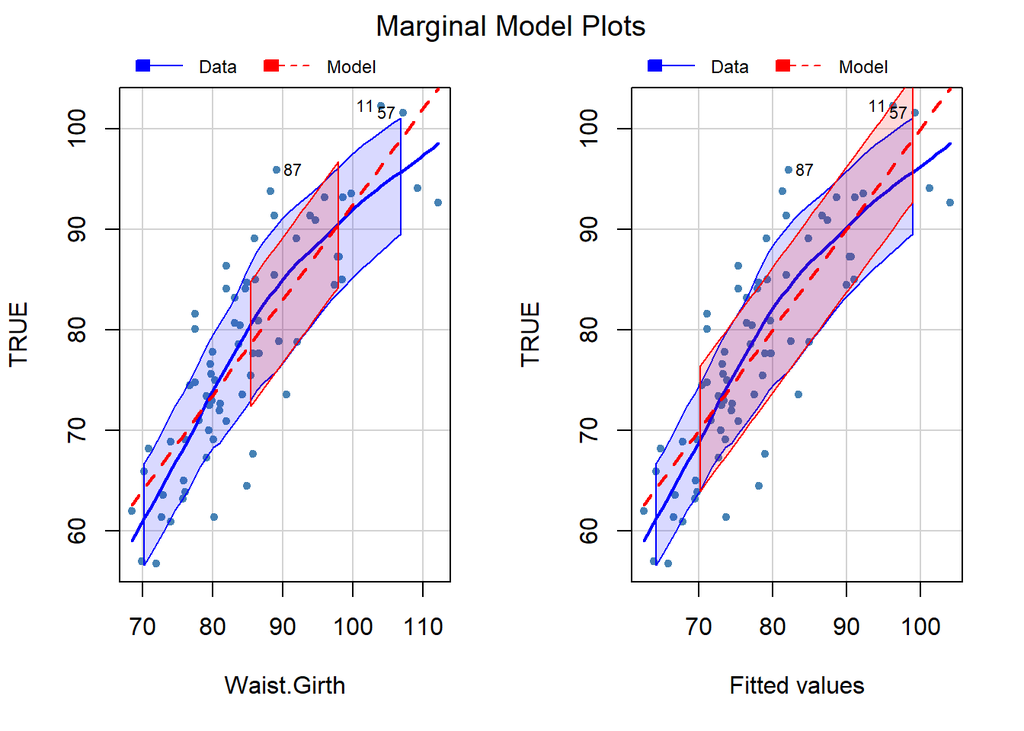

```r
mm1 = marginalModelPlots(modeloSimple, sd = TRUE, id=list(method = "r", n = 3, cex = 0.7, location = "lr"),
                   col = "steelblue", pch = 20, col.quad = c("steelblue", "red"))
```

```r
#modelo simple
rmse_modeloSimple = sqrt(mean(resid(modeloSimple) ** 2))
prediccionesSimple = predict(modeloSimple, datosPruebas)
errorSimple = datosPruebas[["Weight"]] - prediccionesSimple
rmse_pruebaSimple = sqrt(mean(errorSimple) ** 2)
cambioError = (rmse_pruebaSimple -rmse_modeloSimple) / rmse_modeloSimple * 100

rmse_modeloMultiple = sqrt(mean(resid(modeloMultiple)**2))
prediccionesMultiple = predict(modeloMultiple,datosPruebas)
errorMultiple = datosPruebas[["Weight"]] -prediccionesMultiple
rmse_pruebaMultiple = sqrt(mean(errorMultiple) ** 2)
cambioError2 = (rmse_pruebaMultiple - rmse_modeloMultiple) / rmse_modeloMultiple * 100

cat("Rendimiento del modelo de RLS:\n")
```

```
## Rendimiento del modelo de RLS:
```

```r
cat("RMSE para el conjunto de entrenamiento:", round(rmse_modeloSimple, 3), "\n")
```

```
## RMSE para el conjunto de entrenamiento: 6.132
```

```r
cat("RMSE para el conjunto de prueba:", round(rmse_pruebaSimple, 3), "\n")
```

```
## RMSE para el conjunto de prueba: 0.66
```

```r
cat("Cambio en el error:", round(cambioError, 2), "\n")
```

```
## Cambio en el error: -89.24
```

```r
cat("\n")
```

```r
cat("Rendimiento del modelo de RLM:\n")
```

```
## Rendimiento del modelo de RLM:
```

```r
cat("RMSE para el conjunto de entrenamiento:", round(rmse_modeloMultiple, 3), "\n")
```

```
## RMSE para el conjunto de entrenamiento: 2.169
```

```r
cat("RMSE para el conjunto de prueba:", round(rmse_pruebaMultiple, 3), "\n")
```

```
## RMSE para el conjunto de prueba: 0.798
```

```r
cat("Cambio en el error:", round(cambioError2, 2), "\n")
```

```
## Cambio en el error: -63.2
```